# Numpy

Numpy es el paquete fundamental de Python para computación científica.

Agrega la capacidad de usar `arrays N dimensionales`, broadcasting (operaciones elemento a elemento), operaciones matemáticas usadas en el Álgebra Lineal y la conexión con otros lenguajes de programación como Fortan, C/C++.

Los arrays de Numpy tienen ciertas ventajas sobre las listas y diccionarios en la manera de almacenar datos, debido a que proporciona un objecto de almacenamiento de datos conocido como `ndarray`.

```python
%pylab inline
```

```python
import matplotlib.pyplot as plt
import matplotlib as mpl
mpl.rcParams['image.interpolation']= 'nearest'
```

```python
# ndarray vs listas

import timeit
import numpy as np

# Creando un array con  10^7 elementos
arr = np.arange(1e7)

# Convertir ndarray a lista

larr = arr.tolist()

# Las listas no pueden tener broadcasting
# asi que hay que escribir una funcion que emule lo que
# ndarray hace

def lista_tiempo(alista, escalar):
    for i, val in enumerate(alista):
        alista[i] = val * escalar
    return alista
```

```python
%timeit arr *1.1
```

```
The slowest run took 6.03 times longer than the fastest. This could mean that an intermediate result is being cached
1 loops, best of 3: 42.8 ms per loop
```

```python
%timeit lista_tiempo(larr, 1.1)
```

```
1 loops, best of 3: 1.5 s per loop
```

## np.darray

- Bloques contiguos de memoria (sección de memoria) que almacenan una colección de datos:

[figure not shown]

- El objeto `ndarray` es similar a las listas, pero *sólo permite que el mismo tipo de elementos* puedan ser almacenados en columnas. Un `array` es un objeto de Python que es una vista en esta sección de la memoria

[figure not shown]

- Algunos atributos:
  - data
  - shape
  - strides
  - dtype
  - size
  - ndim
- El objeto `ndarray` permite diferentes puntos de vista (sub sections, reshaping, transposition, etc.) sin cambiar nada en memoria sólo la interpretación de los cambios de memoria almacenados.
- Todas las interfaces con esta estructura de datos se escriben en C y el acceso y modificación de las estructuras de datos son por lo tanto bastante rápidas.

## Construcción de arrays

Hay varias maneras de crear un array en Numpy. Veamos algunas de ellas:

```python
# Creemos una lista y hagamos una conexion con la funcion np.array()
alista = [1, 2, 3, 4, 5]
arr = np.array(alista)
arr
```

```
array([1, 2, 3, 4, 5])
```

```python
np.array([1, 2, 3], dtype=np.int)
```

```
array([1, 2, 3])
```

```python
np.array([1, 2, 3], dtype=np.float)
```

```
array([ 1.,  2.,  3.])
```

```python
np.array([1, 2, 3], dtype=np.complex)
```

```
array([ 1.+0.j,  2.+0.j,  3.+0.j])
```

Mostremos con un array 2-d algunos atributos de `ndarray`:

```python
alista1 = np.array([[1, 2], [3, 4], [5, 6]])
type(alista1)
```

```
numpy.ndarray
```

```python
alista1
```

```
array([[1, 2],
       [3, 4],
       [5, 6]])
```

```python
alista1.ndim
```

```
2
```

```python
alista1.shape
```

```
(3, 2)
```

```python
alista1.size
```

```
6
```

```python
alista1.dtype
```

```
dtype('int64')
```

```python
alista1.nbytes
```

```
48
```

```python
# Creando un array de ceros con 5 elementos

arr = np.zeros(5)
arr
```

```
array([ 0.,  0.,  0.,  0.,  0.])
```

```python
# Crear un array de 100 elementos ordenados dede el cero

arr = np.arange(100)
arr
```

```
array([ 0,  1,  2,  3,  4,  5,  6,  7,  8,  9, 10, 11, 12, 13, 14, 15, 16,
       17, 18, 19, 20, 21, 22, 23, 24, 25, 26, 27, 28, 29, 30, 31, 32, 33,
       34, 35, 36, 37, 38, 39, 40, 41, 42, 43, 44, 45, 46, 47, 48, 49, 50,
       51, 52, 53, 54, 55, 56, 57, 58, 59, 60, 61, 62, 63, 64, 65, 66, 67,
       68, 69, 70, 71, 72, 73, 74, 75, 76, 77, 78, 79, 80, 81, 82, 83, 84,
       85, 86, 87, 88, 89, 90, 91, 92, 93, 94, 95, 96, 97, 98, 99])
```

```python
#Un array desde el 20, hasta uno menos que el 100 (99)

arr = np.arange(20, 100)
arr
```

```
array([20, 21, 22, 23, 24, 25, 26, 27, 28, 29, 30, 31, 32, 33, 34, 35, 36,
       37, 38, 39, 40, 41, 42, 43, 44, 45, 46, 47, 48, 49, 50, 51, 52, 53,
       54, 55, 56, 57, 58, 59, 60, 61, 62, 63, 64, 65, 66, 67, 68, 69, 70,
       71, 72, 73, 74, 75, 76, 77, 78, 79, 80, 81, 82, 83, 84, 85, 86, 87,
       88, 89, 90, 91, 92, 93, 94, 95, 96, 97, 98, 99])
```

```python
B = np.array([[5.,6.,7.],[8.,9.,10.]])
B
```

```
array([[  5.,   6.,   7.],
       [  8.,   9.,  10.]])
```

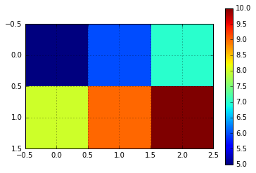

```python
plt.figure()
plt.imshow(B)
plt.colorbar()
plt.grid()
```

```python
# Creando un array de dos dimensiones de ceros 5x5

arr2d = np.zeros((5,5))
arr2d
```

```
array([[ 0.,  0.,  0.,  0.,  0.],
       [ 0.,  0.,  0.,  0.,  0.],
       [ 0.,  0.,  0.,  0.,  0.],
       [ 0.,  0.,  0.,  0.,  0.],
       [ 0.,  0.,  0.,  0.,  0.]])
```

```python
# Creando un array de tres dimensiones de unos de orden 6x6x6
# El método astype() coloca los array con elementos enteros

arr3d = np.zeros((6,6,6)).astype(int) + 1
arr3d
```

```
array([[[1, 1, 1, 1, 1, 1],
        [1, 1, 1, 1, 1, 1],
        [1, 1, 1, 1, 1, 1],
        [1, 1, 1, 1, 1, 1],
        [1, 1, 1, 1, 1, 1],
        [1, 1, 1, 1, 1, 1]],

       [[1, 1, 1, 1, 1, 1],
        [1, 1, 1, 1, 1, 1],
        [1, 1, 1, 1, 1, 1],
        [1, 1, 1, 1, 1, 1],
        [1, 1, 1, 1, 1, 1],
        [1, 1, 1, 1, 1, 1]],

       [[1, 1, 1, 1, 1, 1],
```

[output cut: 26 more lines]

Cuando se trabaja con arrays, Numpy por defecto se enlaza al entorno de Python, es decir, si se está trabajando con Python de 64-bits, entonces los elementos en el array, deben tener precision 64-bits. Podemos especificar el tipo de parametros que deseamos (int, numpy.float16, numpy.float64, numpy.float32) se usa `dtype`.

```python
# Array de cero entero

arr = np.zeros(2, dtype = int)
arr
```

```
array([0, 0])
```

```python
# Array de cero flotante

arr = np.zeros(2, dtype = np.float32)
arr
```

```
array([ 0.,  0.], dtype=float32)
```

```python
# Arrays de 1's

arr1 = np.ones(4, dtype = np.int64)
arr1
```

```
array([1, 1, 1, 1])
```

```python
arr1.dtype
```

```
dtype('int64')
```

```python
# La funcion np.full, que evita la multiplicacion

x1 = 5.4 * np.ones(5)
x2 = np.full(5, 5.4)
```

```python
x1
```

```
array([ 5.4,  5.4,  5.4,  5.4,  5.4])
```

```python
x2
```

```
array([ 5.4,  5.4,  5.4,  5.4,  5.4])
```

```python
# La funcion np.fill

x3 = np.empty(5) # array sin inicializar
x3.fill(4.0)
x3
```

```
array([ 4.,  4.,  4.,  4.,  4.])
```

```python
x4 = np.full(5, 3.0)
x4
```

```
array([ 3.,  3.,  3.,  3.,  3.])
```

```python
# Uso de la funcion np.arange
np.arange(0.0, 10, 1)
```

```
array([ 0.,  1.,  2.,  3.,  4.,  5.,  6.,  7.,  8.,  9.])
```

```python
# Usando la funcion np.linspace

np.linspace(0, 10, 11)
```

```
array([  0.,   1.,   2.,   3.,   4.,   5.,   6.,   7.,   8.,   9.,  10.])
```

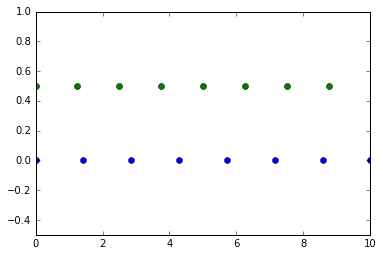

```python
# Ejemplo de la documentación de Numpy

N = 8
y = np.zeros(N)
z1 = np.linspace(0, 10, N, endpoint=True)
z2 = np.linspace(0, 10, N, endpoint=False)
plt.plot(z1, y, 'o')
plt.plot(z2, y + 0.5, 'o')
plt.ylim([-0.5, 1])
plt.show()
```

`np.meshgrid` se utiliza para vectorize funciones de dos variables:

```python
x = np.array([1, 2, 3])
y = np.array([10, 20, 30])
XX, YY = np.meshgrid(x, y)
ZZ = XX + YY
ZZ
```

```
array([[11, 12, 13],
       [21, 22, 23],
       [31, 32, 33]])
```

```python
XX
```

```
array([[1, 2, 3],
       [1, 2, 3],
       [1, 2, 3]])
```

```python
YY
```

```
array([[10, 10, 10],
       [20, 20, 20],
       [30, 30, 30]])
```

`np.ones_like, np.zeros_like, np.full_like` y `np.empty_like` son funciones que sirven para crear nuevos arrays que compartan ciertas propiedades o atributos.

```python
A = np.zeros((4,10))
B_2 = np.ones_like(A)
A, B_2
```

```
(array([[ 0.,  0.,  0.,  0.,  0.,  0.,  0.,  0.,  0.,  0.],
        [ 0.,  0.,  0.,  0.,  0.,  0.,  0.,  0.,  0.,  0.],
        [ 0.,  0.,  0.,  0.,  0.,  0.,  0.,  0.,  0.,  0.],
        [ 0.,  0.,  0.,  0.,  0.,  0.,  0.,  0.,  0.,  0.]]),
 array([[ 1.,  1.,  1.,  1.,  1.,  1.,  1.,  1.,  1.,  1.],
        [ 1.,  1.,  1.,  1.,  1.,  1.,  1.,  1.,  1.,  1.],
        [ 1.,  1.,  1.,  1.,  1.,  1.,  1.,  1.,  1.,  1.],
        [ 1.,  1.,  1.,  1.,  1.,  1.,  1.,  1.,  1.,  1.]]))
```

## Funciones para crear matrices

```python
np.identity(4)
```

```
array([[ 1.,  0.,  0.,  0.],
       [ 0.,  1.,  0.,  0.],
       [ 0.,  0.,  1.,  0.],
       [ 0.,  0.,  0.,  1.]])
```

```python
np.eye(3, k=1)
```

```
array([[ 0.,  1.,  0.],
       [ 0.,  0.,  1.],
       [ 0.,  0.,  0.]])
```

```python
np.eye(3, k=-1)
```

```
array([[ 0.,  0.,  0.],
       [ 1.,  0.,  0.],
       [ 0.,  1.,  0.]])
```

```python
np.diag(np.arange(0, 20, 5))
```

```
array([[ 0,  0,  0,  0],
       [ 0,  5,  0,  0],
       [ 0,  0, 10,  0],
       [ 0,  0,  0, 15]])
```

```
0.66699017275186356
```

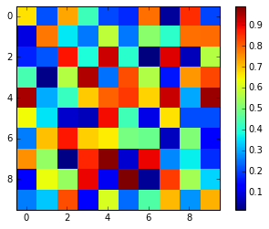

```python
#  np.random.random, retorna floats de manera aleatoria en [0.0, 1.0)

A = np.random.random((10,10))
plt.imshow(A)
plt.colorbar()
A[0,0]
```

## Indexar y dividir

```python
# Indexar un array 1-d

a = np.arange(0, 11)
a
a[0]
```

```
0
```

```python
a[-1]
```

```
10
```

Para seleccionar un rango de elementos, digamos desde el segundo hasta el último elemento, menos uno podemos utilizar `slices` para los índices:

```python
a[1:-1]
```

```
array([1, 2, 3, 4, 5, 6, 7, 8, 9])
```

```python
a[1:-1:2]
```

```
array([1, 3, 5, 7, 9])
```

Para seleccionar los cinco primeros y los últimos cinco elementos de una matriz, podemos usar `:5` y `-5:`, desde que `m` o `n` se omite en `m: n`:

```python
a[:5]
```

```
array([0, 1, 2, 3, 4])
```

```python
a[-5:]
```

```
array([ 6,  7,  8,  9, 10])
```

Para invertir el array y seleccionar sólo cada segundo valor, podemos utilizar `::-2`

```python
a[::-2]
```

```
array([10,  8,  6,  4,  2,  0])
```

```python
# Para array multidimensionales

f = lambda m, n: n + 10 * m

# np.fromfunction construye un array ejecutando
# una funcion sobre cada una de sus coordenadas

a1 = np.fromfunction(f, (6, 6), dtype=int)
a1
```

```
array([[ 0,  1,  2,  3,  4,  5],
       [10, 11, 12, 13, 14, 15],
       [20, 21, 22, 23, 24, 25],
       [30, 31, 32, 33, 34, 35],
       [40, 41, 42, 43, 44, 45],
       [50, 51, 52, 53, 54, 55]])
```

```python
a1[:, 1]
```

```
array([ 1, 11, 21, 31, 41, 51])
```

```python
a1[1, :]
```

```
array([10, 11, 12, 13, 14, 15])
```

```python
a1[:3, :3]
```

```
array([[ 0,  1,  2],
       [10, 11, 12],
       [20, 21, 22]])
```

```python
a1[3:, :3]
```

```
array([[30, 31, 32],
       [40, 41, 42],
       [50, 51, 52]])
```

```python
a1[::2, ::2]   # cada segundo elemento empezando desde 0,0
```

```
array([[ 0,  2,  4],
       [20, 22, 24],
       [40, 42, 44]])
```

```python
a1[1::2, 1::3] # cada segundo y tercer elemento empezando desde 1,1
```

```
array([[11, 14],
       [31, 34],
       [51, 54]])
```

```python
# Index para valores booleanos

A = np.linspace(0, 1, 11)
A[np.array([0, 2, 4])]
A[[0, 2, 4]]  # Se puede utilizar el indexado de las listas
```

```
array([ 0. ,  0.2,  0.4])
```

```python
A > 0.5
```

```
array([False, False, False, False, False, False,  True,  True,  True,
        True,  True], dtype=bool)
```

```python
A[A> 0.5]
```

```
array([ 0.6,  0.7,  0.8,  0.9,  1. ])
```

## Reshaping y resizing

Reshaping(remodelado) es una técnica para remodelar un array y alterar la manera que son interpretados.

```python
a2 = np.array([[1, 2], [3, 4]])
np.reshape(a2, (1, 4))
```

```
array([[1, 2, 3, 4]])
```

```python
a2.reshape(4)
```

```
array([1, 2, 3, 4])
```

Podemos reformular los arrays de diversas maneras. Por ejemplo si tenemos un array de 25 elementos, podemos expresar esto como una matriz 5 x 5 o como una matriz de 3 dimensiones.

```python
# Creando un array con np.arange

arr1 = np.arange(1000)

# Reformulamos el array como una matriz 10x10x 10

arr2 = arr1.reshape(10, 10, 10)
```

```python
# Otra manera de llamar a reshape es:

arr3 = np.reshape(arr1, (10, 10, 10))
```

```python
# Inversamente podemos 'allanar' los arrays

arr4 = np.zeros((10, 10, 10, 10))
arr5 = arr4.ravel()

print (arr5.shape)
```

```
(10000,)
```

## Uniendo arrays

```python
b1 = np.arange(5)
b1
```

```
array([0, 1, 2, 3, 4])
```

```python
np.vstack((b1, b1, b1)) # se apila el array verticalmente
```

```
array([[0, 1, 2, 3, 4],
       [0, 1, 2, 3, 4],
       [0, 1, 2, 3, 4]])
```

```python
np.hstack((b1, b1, b1)) # se apila el array horizontalmente
```

```
array([0, 1, 2, 3, 4, 0, 1, 2, 3, 4, 0, 1, 2, 3, 4])
```

```python
# Corrigiendo np.hstack para ingresar las entradas como columnas.

b1 = b1[:, np.newaxis]
np.hstack((b1, b1, b1))
```

```
array([[0, 0, 0],
       [1, 1, 1],
       [2, 2, 2],
       [3, 3, 3],
       [4, 4, 4]])
```

## Operaciones con Arrays

```python
A = np.ones((5,5))
A +A
```

```
array([[ 2.,  2.,  2.,  2.,  2.],
       [ 2.,  2.,  2.,  2.,  2.],
       [ 2.,  2.,  2.,  2.,  2.],
       [ 2.,  2.,  2.,  2.,  2.],
       [ 2.,  2.,  2.,  2.,  2.]])
```

```python
A*A
```

```
array([[ 1.,  1.,  1.,  1.,  1.],
       [ 1.,  1.,  1.,  1.,  1.],
       [ 1.,  1.,  1.,  1.,  1.],
       [ 1.,  1.,  1.,  1.,  1.],
       [ 1.,  1.,  1.,  1.,  1.]])
```

```python
np.dot(A,A)
```

```
array([[ 5.,  5.,  5.,  5.,  5.],
       [ 5.,  5.,  5.,  5.,  5.],
       [ 5.,  5.,  5.,  5.,  5.],
       [ 5.,  5.,  5.,  5.,  5.],
       [ 5.,  5.,  5.,  5.,  5.]])
```

```python
A * 5  # se realiza broadcasting
```

```
array([[ 5.,  5.,  5.,  5.,  5.],
       [ 5.,  5.,  5.,  5.,  5.],
       [ 5.,  5.,  5.,  5.,  5.],
       [ 5.,  5.,  5.,  5.,  5.],
       [ 5.,  5.,  5.,  5.,  5.]])
```

Más acerca del uso de broadcasting en el siguiente enlace: http://docs.scipy.org/doc/numpy/user/basics.broadcasting.html

```python
# Mas ejemplos

x = np.array([[1, 2], [3,4]])
y = np.array([[5, 6],[7,8]])
x + y
y - x
x * y
y /x

# Operaciones con escalares

x * 2
2 ** x
(y/2).dtype
```

```
dtype('float64')
```

```python
# Arrays incompatibles. Surge una excepcion ValueError

x = np.array([5, 6, 6, 8]).reshape(2, 2)
z = np.array([1, 2, 2, 4])
x/z
```

```
---------------------------------------------------------------------------
ValueError                                Traceback (most recent call last)
<ipython-input-139-3d85168fd960> in <module>()
      3 x = np.array([5, 6, 6, 8]).reshape(2, 2)
      4 z = np.array([1, 2, 2, 4])
----> 5 x/z

ValueError: operands could not be broadcast together with shapes (2,2) (4,)
```

## Funciones elementales en Numpy

Cada una de estas funciones tiene como entrada un array (de dimensión arbitraria) y devuelve una nueva matriz de la misma forma, donde a cada elemento del array de entrda se le ha aplicado la función.

- `np.cos, np.sin, np.tan`
- `np.arccos, np.arcsin. np.arctan`
- `np.log, np.log2, np.log10`
- `np.sqrt`
- `np.exp`

```python
x = np.linspace(-1, 1, 10)
y = np.sin(np.pi * x)
np.round(y, decimals=4)
```

```
array([-0.    , -0.6428, -0.9848, -0.866 , -0.342 ,  0.342 ,  0.866 ,
        0.9848,  0.6428,  0.    ])
```

Más operaciones con funciones elementales proporcionadas por Numpy son:

- `np.add, np.subtract`
- `np.multiply, np.divide`
- `np.power`
- `np.floor, np.ceil, np.rint`
- `np.real, np.imag, np.conj`
- `np.round`

```python
z = np.arange(10)
z
np.log(z)
```

```
array([       -inf,  0.        ,  0.69314718,  1.09861229,  1.38629436,
        1.60943791,  1.79175947,  1.94591015,  2.07944154,  2.19722458])
```

```python
np.power(z, 2)
np.exp(z+1)
```

```
array([  2.71828183e+00,   7.38905610e+00,   2.00855369e+01,
         5.45981500e+01,   1.48413159e+02,   4.03428793e+02,
         1.09663316e+03,   2.98095799e+03,   8.10308393e+03,
         2.20264658e+04])
```

```python
# Otros ejemplos

x = np.linspace(-1, 1, 11)
np.add(np.sin(x) ** 2, np.cos(x) ** 2)
```

```
array([ 1.,  1.,  1.,  1.,  1.,  1.,  1.,  1.,  1.,  1.,  1.])
```

```python
def h(x):
    return 1 if x >0 else 0

h(-1)
```

```
0
```

```python
h(1)
```

```
1
```

```python
# Esta funciones no funciona para arrays de Numpy

x = np.linspace(-5, 5, 11)
h(x)
```

```
---------------------------------------------------------------------------
ValueError                                Traceback (most recent call last)
<ipython-input-152-633f96dba8a2> in <module>()
      2
      3 x = np.linspace(-5, 5, 11)
----> 4 h(x)

<ipython-input-149-82e807e1527d> in h(x)
      1 def h(x):
----> 2     return 1 if x >0 else 0
      3
      4 h(-1)

ValueError: The truth value of an array with more than one element is ambiguous. Use a.any() or a.all()
```

Usando la función `np.vectorize` que trabaja con arrays, para vectorizar una función que trabaje con Numpy:

```python
fh = np.vectorize(h)
fh(x)
```

```
array([0, 0, 0, 0, 0, 0, 1, 1, 1, 1, 1])
```

Otros tipos de funciones soportadas por Numpy, que retorna un escalar como salida son:

- `np.mean`
- `np.std`
- `np.var`
- `np.sum`
- `np.prod`
- `np.cumsum`
- `np.cumprod`
- `np.min, np.max`
- `np.argmin, np.argmax`
- `np.all, np.any`

```python
d1 = np.random.normal(size=(15, 15))
np.mean(d1)
```

```
0.021625293919221768
```

```python
d1.mean()
```

```
0.021625293919221768
```

```python
d2 = np.arange(1,10).reshape(3,3)
d2.sum()
```

```
45
```

```python
d2.sum(axis=0)
```

```
array([12, 15, 18])
```

```python
d2.sum(axis=1)
```

```
array([ 6, 15, 24])
```

```python
# Otro ejemplos

d3 = np.array([[3, 5], [7, 9]])
np.var(d3)
```

```
5.0
```

```python
np.var(d3, axis=0)
```

```
array([ 4.,  4.])
```

```python
np.var(d3, axis =1)
```

```
array([ 1.,  1.])
```

## Operaciones con matrices

Una de las principales aplicaciones de los arrays es la representación de los conceptos matemáticos de vectores, matrices y tensores, de uso frecuente en el cálculo de operaciones vectoriales y matriciales tales como el producto interno, matricial y el tensorial. Algunas de las funciones que realizan estas operaciones son:

- np.dot
- np.inner
- np.cross
- np.tensordot
- np.outer
- np.kron

```python
a = np.arange(1, 7).reshape(2, 3)
a
```

```
array([[1, 2, 3],
       [4, 5, 6]])
```

```python
b= np.arange(1, 7).reshape(3, 2)
b
```

```
array([[1, 2],
       [3, 4],
       [5, 6]])
```

```python
np.dot(a, b) # Multiplicacion matricial
```

```
array([[22, 28],
       [49, 64]])
```

```python
np.dot(b,a)
```

```
array([[ 9, 12, 15],
       [19, 26, 33],
       [29, 40, 51]])
```

La función `np.dot` es usada para la multiplicación de un array y un vector, como los se usa en la resolución de sistemas lineales:

```python
c = np.arange(9).reshape(3, 3)
c
```

```
array([[0, 1, 2],
       [3, 4, 5],
       [6, 7, 8]])
```

```python
x = np.arange(3)
x
```

```
array([0, 1, 2])
```

```python
np.dot(c, x)
```

```
array([ 5, 14, 23])
```

```python
# Para expresiones complicadas es un poco complicado usar esa funcion

f = np.random.rand(3, 3)
g = np.random.rand(3, 3)
Ap = np.dot(g, np.dot(f, np.linalg.inv(g)))
Ap
```

```
array([[-2.81289683,  1.15161144,  2.92115229],
       [-3.66184591,  1.22007983,  3.37445687],
       [-3.3291301 ,  1.29056036,  3.50603918]])
```

```python
# Producto interno entre dos vectores

np.inner(x, x)
```

```
5
```

```python
np.dot(x,x)
```

```
5
```

```python
y = x[:, np.newaxis]
np.dot(y.T, y)
```

```
array([[5]])
```

```python
# Producto exterior

w = np.array([2, 4, 6])
np.outer(w, w)
```

```
array([[ 4,  8, 12],
       [ 8, 16, 24],
       [12, 24, 36]])
```

La función `np.kron` puede ser usado para calcular el producto tensorial de array de arbitrarias dimensiones.

```python
np.kron(np.ones((2,2)), np.identity(2))
```

```
array([[ 1.,  0.,  1.,  0.],
       [ 0.,  1.,  0.,  1.],
       [ 1.,  0.,  1.,  0.],
       [ 0.,  1.,  0.,  1.]])
```

```python
np.kron(np.identity(2), np.ones((2,2)))
```

```
array([[ 1.,  1.,  0.,  0.],
       [ 1.,  1.,  0.,  0.],
       [ 0.,  0.,  1.,  1.],
       [ 0.,  0.,  1.,  1.]])
```

## Numpy.random

```python
# Numeros entre 0 y 1, desde una distribucion uniforme en [0,1>

np.random.rand(3,2)
```

```
array([[ 0.18348346,  0.04460783],
       [ 0.78680937,  0.85822872],
       [ 0.07122759,  0.22148672]])
```

```
(150, 100)
```

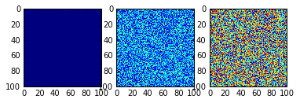

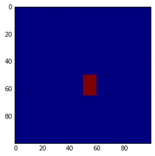

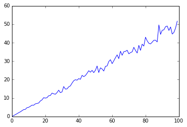

```python
# Retorna elementos aleatorios entre [0, 1>

e = np.random.random((100,100,100)) * np.arange(100)
figure()
subplot(1,3,1)
imshow(e[:,:,0], vmax=100)
subplot(1,3,2)
imshow(e[:,:,50], vmax=100)
subplot(1,3,3)
imshow(e[:,:,99], vmax=100)

index = np.zeros((100,100), dtype=bool)
index[50:65,50:60] = True
print (e[index,:].shape)


figure()
imshow(index)
figure()
plot(e[index,:].mean(axis=0))
```

Considerar una función que simula a `N` caminantes al azar cada uno tomando M pasos y que alcula la distancia más alejada del punto de partida obtenido por cualquiera de los caminantes aleatorios:

```python
import numpy as np

def caminante_aleatorio_max_distancia(M,N):

    """
    Simula N caminantes, tomando n pasos y que devuelve la
    distancia mas alejada tomada desde el punto de partida
    de un caminante aleatorio
    """

    # random.randn devuelve numeros desde una distribucion normal
    camino = [np.random.randn(M).cumsum() for _ in range(N)]
    return np.max(np.abs(camino))
```

```python
%prun caminante_aleatorio_max_distancia(400, 10000)
```

Dibujemos un histograma de 10.000 números aleatorios producidos por cada función:

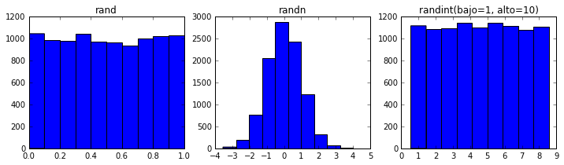

```python
fig, axes = plt.subplots(1, 3, figsize=(12, 3))
axes[0].hist(np.random.rand(10000))
axes[0].set_title("rand")
axes[1].hist(np.random.randn(10000))
axes[1].set_title("randn")
axes[2].hist(np.random.randint(low=1, high=10, size=10000), bins=9, align='left')
axes[2].set_title("randint(bajo=1, alto=10)")
```

`np.random.choice` genera una muestra desde un array 1-d.

```python
np.random.choice(7, 4)
```

```
array([6, 4, 2, 2])
```

```python
# Generamos una muestra sin reemplazamiento

np.random.choice(5, 3, replace=False)
```

```
array([0, 1, 2])
```

Cuando se trabaja con generación de números aleatorios, puede ser útil el `seed` del generador de números aleatorios. `seed` es un número que inicializa el generador de números aleatorios para un estado específico, de manera que una vez que ha sido usado con un número específico siempre genera la misma secuencia de números aleatorios.

```python
np.random.seed(12345)
np.random.rand()
```

```
0.9296160928171479
```

```python
# Otra vez aparece el mismo valor

np.random.seed(12345); np.random.rand()
```

```
0.9296160928171479
```

```python
prng = np.random.RandomState(12345)
prng.rand(2, 4)
```

```
array([[ 0.92961609,  0.31637555,  0.18391881,  0.20456028],
       [ 0.56772503,  0.5955447 ,  0.96451452,  0.6531771 ]])
```